# Graphs everywhere.

### VISN 8 AI summit

#### 1.Gen AI generate knowledge graphs: The case for machine learning abstraction of clinical semantics.

#### 2.Referral networks on a scale

#### 3.A team of AI-Agents

### [Alon Ben-Ari MD MSc](https://alon-benari.github.io/)

## What are graphs.

### Graphs are mathematical entities that model relationship between two entities.

#### Put differently:

### If we have different entities, we can model their relationship mathematically.

### e.g. a network is a graph.

### What is a Knowledge Graph?

A **knowledge graph**, also known as a **semantic network**, represents a network of real-world entities—such as objects, events, situations, or concepts—and illustrates the relationships between them.

Cases:

1. LinkedIn knowledge graph used to abstact recommendations for new connections
2. Amazon graph for products to recommend products
3. Google knowledge graph (2012): Broaden the search and recommend relevant information to the search.

[figure not shown]

## Abstracting clinical semantics from clinical notes:

1. Toward **clinically Semantic** knowledge graph that is aimed at clinical thinking. (hard questions:'patient functional capacity','deep wound infection')
2. The case for clinical semantic abstraction in surgical site infections.

## What else can be done with a 'Patient Graph'?

## Motivation:

### 0. Help with data tracking and reporting for infectious disease specifically for surgical site infections.

### 1. Explore options of scaling the operation of chart review for the purpose of quality assurance.

## Method

### 0. For operation purposes review vascular surgical site infections from local VASQIP set.

### 1.Abstract sugical notes for POD +90.

### 2.Design a prompt to abstract all surgical notes authored by attending/residents/nursing daily reports ( including dressing changes)

### 3. Use an LLM to abstract clinically meaningful features i.e. clinical semantics.

## Goals:

### 0.Established a proof of concept for such a pipeline.

### 1.Abtsract clinical semantics.

### 2.Can we stage a predicive model for surgical site infections using features abstracted from clinical notes?.

## Credit to The Microsoft/Dell Federal Data Science Team @ GovCloud on Azure

1. Mr. Joe Fisher, PhD,
2. Mr. Michael Slentz,
3. Ms Arpita Parmar

### Prompt:

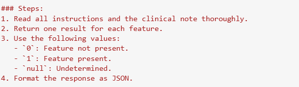

## prompt for feature abstraction

[figure not shown]

## Results

1. 26 patients
2. 5 positive cases
3. about 2500 text notes.

[figure not shown]

## Classification: Intuition 1

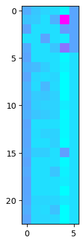

## Classifier: Intuition 2:

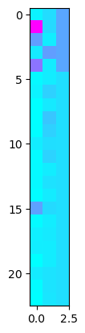

## Intuition 3: Projecting to a 2D plane,

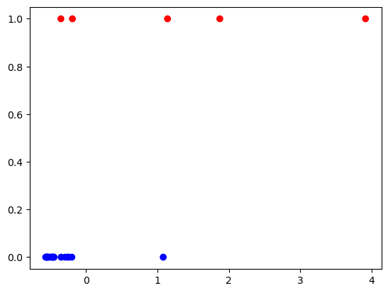

### Random Forest Modeling

[figure not shown]

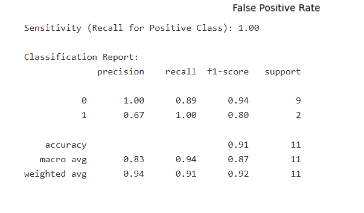

## Future Work:

### 0. More patients.

### 1.LLMs for the abstraction of clinical features, using a controlled vocabulary(ontology).

### 2.Future applications: Knowledge Graphs of Clinical Semantics for surgical assessment, quick patient reference

## Referral Networks

### Who consults who in a large health care system

### Applying network analysis to referral network on a scale.

### Formally finding similarities/communicties between services.

### Can similarities betwen clinical services across the enterprise can have operational synergy?.

[Scaling Laws in Referral Networks](https://www.medrxiv.org/content/10.1101/2024.11.06.24316731v1)

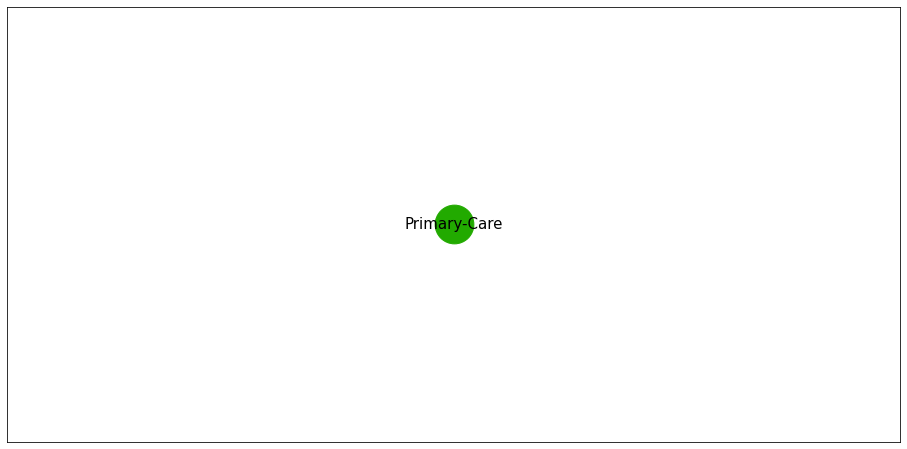

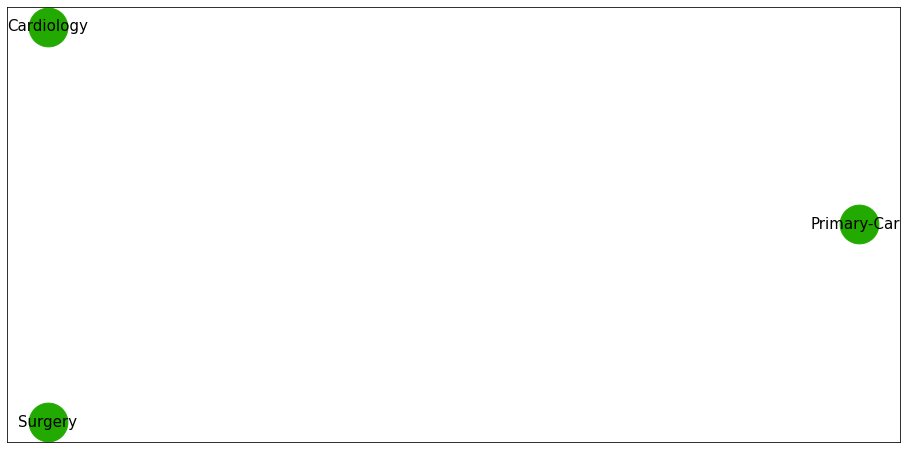

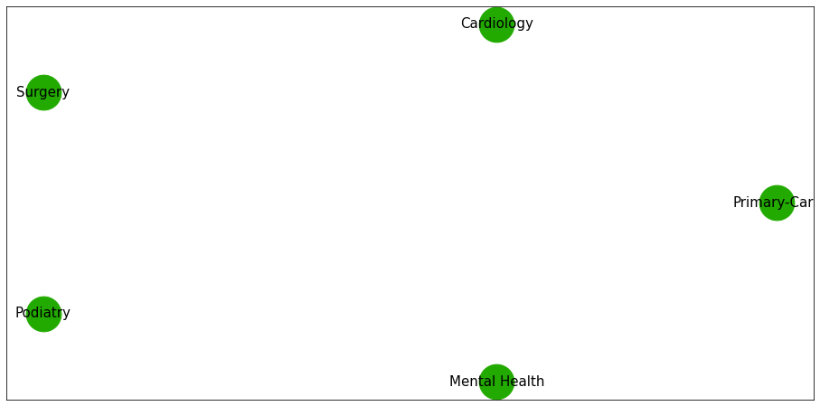

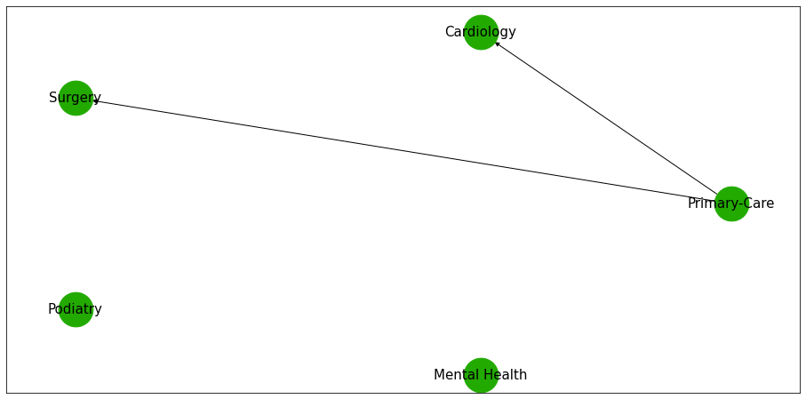

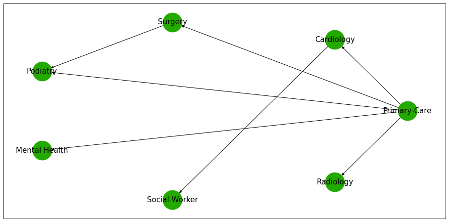

### Referral network of large healthcare system - how would that [look like](https://alon-benari.github.io/chord640.html)?

## Triangles every where

- The idea of a friend of a friend.
- How about triangles for whom communication is bi-directional? how common are they?
- What might be their operational significance.

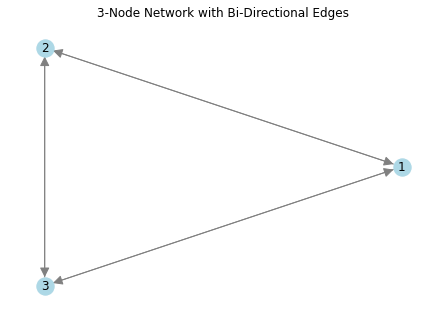

## Some observations from a prominent healthcare

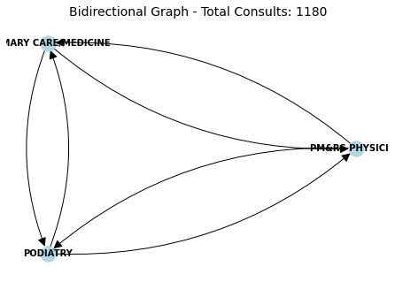

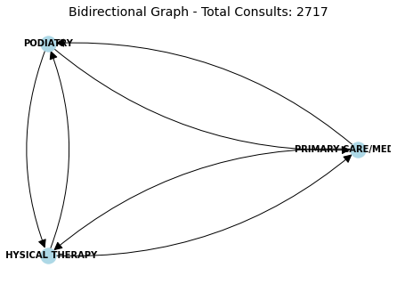

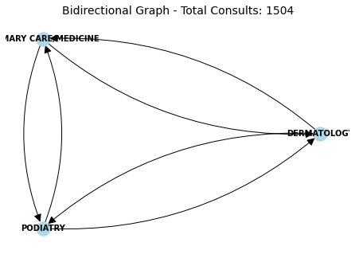

## What can be done and how?

### What would be the effect of joint clinics on access and timeliness of care.

## What between Amazon product recommender and clinical efficiency?

## A word about word embedding

A technique in natural language processing (NLP) that represents words as vectors in a multi-dimensional space.

- **Boy**: [1, 2], **Girl**: [9, 2]

[figure not shown]

## Capturing network topology in a formal way

[figure not shown]

## Word Embedding on a network

## Can we capture the geometry of a network, with a unique representation?

#### Node2Vec: algorithm that generates vector representations of nodes in a graph

Aditya Grover, Jure Leskovec node2vec: Scalable Feature Learning for Networks, Proceedings of the 22nd ACM SIGKDD International Conference on Knowledge Discovery and Data Mining, 2016

- Word embedding on a graph? - borrow the idea of word embedding to networks, to get a numeric representation of a node, captuing the **topology** of the vicinity of the node.
- What does it mean? -> capture the whole network topology
- What can you do with this?

## Node2Vec algorithm:

Let's develop an intuition

[figure not shown]

## Embedding for consult service for a healthcare system

### ** Compute Embedding for a weighted network by referral count

### ** project on 2D

[figure not shown]

## Zooming in

[figure not shown]

### Node Names and Their IDs

- **EMG - ELECTROMYOGRAM**: 212
- **HAND SURGERY**: 405
- **PAIN CLINIC**: 420
- **PM&R ASSIST TECH CLINIC**: 240
- **SPINAL CORD INJURY:** :210

## A different take: A closer look at Care in the Community (CITC) across the enterprise.

### Get embedding for for CITC for every healthcare system across VHA.

### Project on 2D plane and color by the magnitude of the embeding.

[figure not shown]

## Let's blow some life into this network....

```
[d3blocks] >INFO> Animation.save using <class 'matplotlib.animation.HTMLWriter'>
```

[output not shown]

[figure not shown]

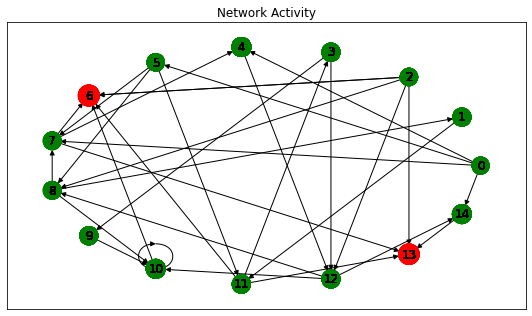

### Recap.

### What else do we need.

### We know:

- rate of referrals
- time it take to service the referral.
- structure of the network i.e. "who refers to who"

### We are interested in:

- count of patients in the queue
- count of clinics that are in **overflow**.

### How might this look for a whole healthcare system.

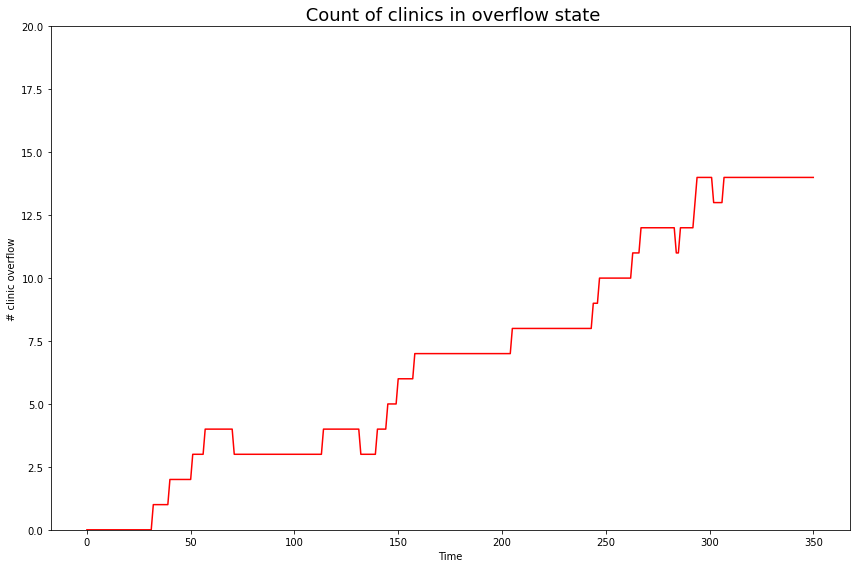

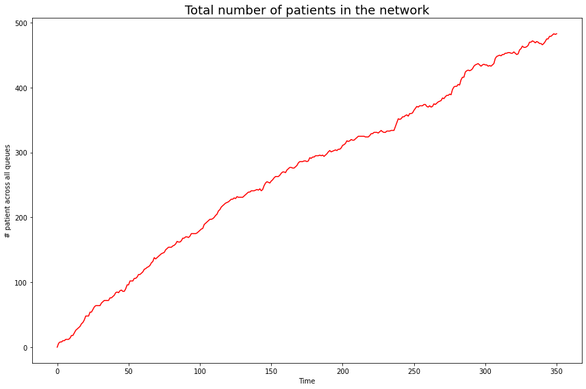

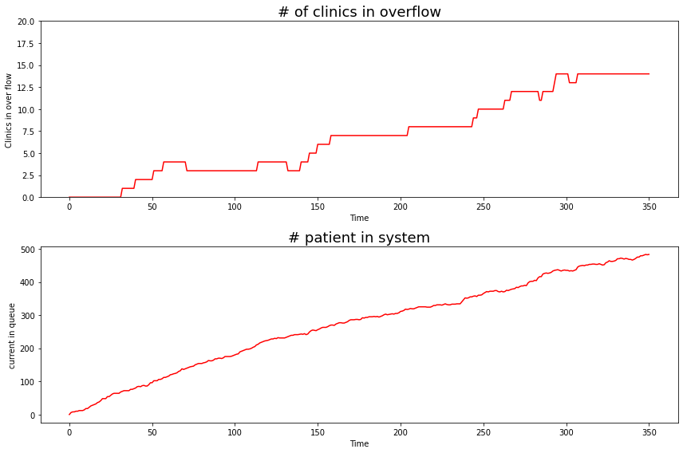

## What can be done to mitigate this?

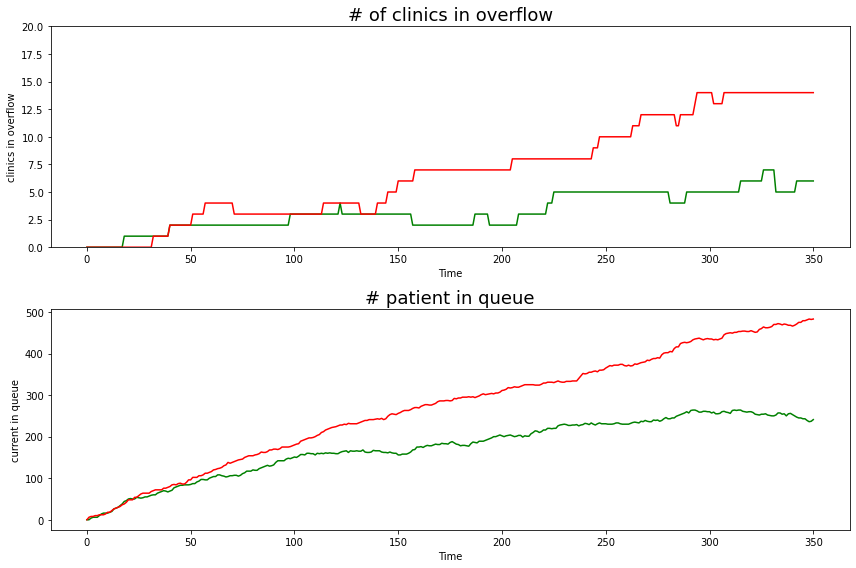

## Rate correction.

-- What if we can correct the time constan as the simulation progresses? -- Can we estimate what needs to be the expected time to for each service to make sure the queue is not too long?

## Look at what happens at step 180.

```
Completed: 365 steps
Run time: 0:00:03.203031
Simulation finished
```

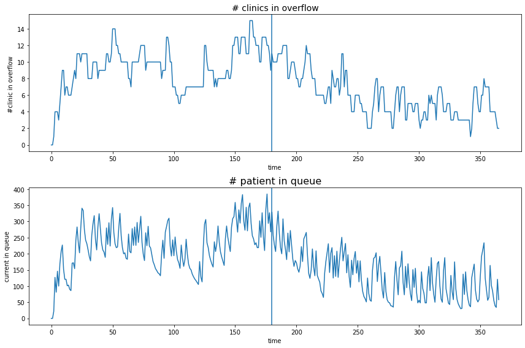

## Whats next for clinical efficiency

### What if we several services at 10-30% of the time can work together? What effect would this have.?

### What can be learned from reviewing unique services across the board?

### This work was [posted](https://www.medrxiv.org/content/10.1101/2024.11.06.24316731v1) on medRxiv

## AI Agent take on the Return To Office (RTO)

### [Agentic Systems](https://alon-benari.github.io/multiple_agents_v2.slides.html#/)